# individual

Tanner Dunn

4/16/2021

```r
library(tidyverse)
```

```r
library(ggplot2)
library(lubridate)
acc <- read.csv("https://raw.githubusercontent.com/xdaiISU/ds202materials/master/hwlabs/fars2017/accident.csv", stringsAsFactors = FALSE)
person <- read.csv("https://raw.githubusercontent.com/xdaiISU/ds202materials/master/hwlabs/fars2017/person.csv", stringsAsFactors = FALSE)
```

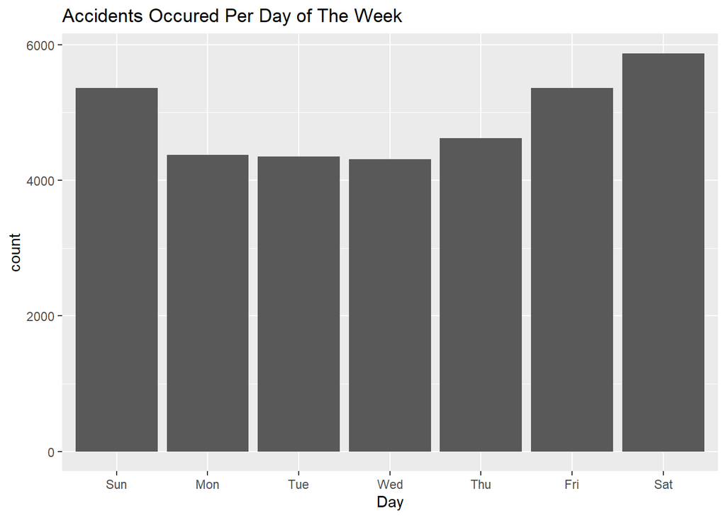

```r
ggplot(acc, aes(wday(DAY_WEEK, label = T))) + geom_bar() + ggtitle("Accidents Occured Per Day of The Week") + xlab("Day")
```

In this visual it is clear the weekend(Friday - Sunday) has the most accidents.

2

```r
q2 <- person %>%
  filter(INJ_SEV == 4)
head(q2, 15)
```

```
##    STATE ST_CASE VE_FORMS VEH_NO PER_NO STR_VEH COUNTY DAY MONTH HOUR MINUTE
## 1      1   10001        1      1      1       0     73  19     2   23     35
## 2      1   10002        1      1      1       0     89  14     2   14     59
## 3      1   10003        3      2      1       0    101  31     1   20     31
## 4      1   10004        1      1      1       0     73   1     1   16     55
## 5      1   10005        1      1      1       0     13   1     1   20      0
## 6      1   10006        2      1      1       0     49   6     1   18     40
## 7      1   10007        2      1      1       0     73  11     1   17     57
## 8      1   10008        1      1      1       0      3  11     1   16     50
## 9      1   10009        1      1      1       0     87  11     1   14     30
## 10     1   10011        2      1      1       0     87  15     1    4     35
## 11     1   10011        2      2      1       0     87  15     1    4     35
## 12     1   10012        2      1      1       0     85  19     1   21     50
## 13     1   10013        2      1      1       0     83   1     1   18     34
## 14     1   10013        2      1      2       0     83   1     1   18     34
```

[output cut: 113 more lines]

3

```r
q3_part1 <- q2 %>%
  select(STATE, MAKE, INJ_SEV) %>%
  group_by(STATE, MAKE) %>%
  summarise(count = n())
q3_part2 <- q3_part1 %>%
  na.omit %>%
  group_by(STATE) %>%
  top_n(1, count)

head(q3_part2, 50)
```

```
## # A tibble: 50 x 3
## # Groups:   STATE [47]
##    STATE  MAKE count
##    <int> <int> <int>
##  1     1    12   138
##  2     2    12     9
##  3     4    20    88
##  4     5    20    88
##  5     6    49   351
##  6     8    12    63
##  7     8    37    63
##  8     9    37    28
##  9    10    37    12
## 10    11    37     5
## # ... with 40 more rows
```

4.)

I could not get map_data to compile and I looked all over the internet and tried adding and removing different libraries and it wouldn’t compile. I am going to leave this code snipit out so that the rest of problems compile

```r
names_dat <- readxl::read_xlsx("C:/Spring2021/ds202/names.xlsx")
names_dat$`State Code` = as.numeric(names_dat$`State Code`)
state_codes = names_dat %>% group_by(`State Name`, `State Code`) %>% summarise(n = n()) %>% dplyr::select(`State Name`, `State Code`)
```

```r
#state <- map_data("state")
#dat1 <- q2 %>% group_by(STATE,MAKE) %>%
#  right_join(state,by=c('STATE'='group')) %>%
#  summarize(avgLong=mean(long),avgLat=mean(lat))

#ggplot(state,aes(x='long',y='lat')) + geom_polygon(aes(group=group)) + geom_text(aes(label=MAKE),data=dat1)
```

```r
q5 <-left_join(person, acc, by="ST_CASE")
head(q5, 2)
```

```
##   STATE.x ST_CASE VE_FORMS.x VEH_NO PER_NO STR_VEH COUNTY.x DAY.x MONTH.x
## 1       1   10001          1      1      1       0       73    19       2
## 2       1   10002          1      1      1       0       89    14       2
##   HOUR.x MINUTE.x RUR_URB.x FUNC_SYS.x HARM_EV.x MAN_COLL.x SCH_BUS.x MAKE
## 1     23       35         2          1        38          0         0   20
## 2     14       59         2          1         1          0         0   37
##   MAK_MOD BODY_TYP MOD_YEAR TOW_VEH SPEC_USE EMER_USE ROLLOVER IMPACT1 FIRE_EXP
## 1   20421       15     2004       1        0        0        0      12        0
## 2   37402       14     2005       0        0        0        9       0        0
##   AGE SEX PER_TYP INJ_SEV SEAT_POS REST_USE REST_MIS AIR_BAG EJECTION EJ_PATH
## 1  42   1       1       4       11       20        0       1        1       9
## 2  43   1       1       4       11        3        0       8        0       0
##   EXTRICAT DRINKING ALC_DET ALC_STATUS ATST_TYP ALC_RES DRUGS DRUG_DET DSTATUS
## 1        0        0       9          0        0     996     0        8       0
## 2        0        9       9          2        1       0     9        8       2
##   DRUGTST1 DRUGTST2 DRUGTST3 DRUGRES1 DRUGRES2 DRUGRES3 HOSPITAL DOA DEATH_DA
## 1        0        0        0        0        0        0        0   7       19
## 2        1        1        1      605      600      996        0   7       14
##   DEATH_MO DEATH_YR DEATH_HR DEATH_MN DEATH_TM LAG_HRS LAG_MINS P_SF1 P_SF2
## 1        2     2017       23       35     2335       0        0     0     0
## 2        2     2017       14       59     1459       0        0     0     0
##   P_SF3 WORK_INJ HISPANIC RACE LOCATION STATE.y VE_TOTAL VE_FORMS.y PVH_INVL
## 1     0        0        7    1        0       1        1          1        0
## 2     0        0        7    1        0       1        1          1        0
##   PEDS PERNOTMVIT PERMVIT PERSONS COUNTY.y CITY DAY.y MONTH.y YEAR DAY_WEEK
## 1    0          0       1       1       73  330    19       2 2017        1
## 2    0          0       1       1       89 1730    14       2 2017        3
##   HOUR.y MINUTE.y NHS RUR_URB.y FUNC_SYS.y RD_OWNER ROUTE TWAY_ID TWAY_ID2
## 1     23       35   1         2          1        1     1   I-459
## 2     14       59   1         2          1        1     1   I-565
##   MILEPT LATITUDE  LONGITUD SP_JUR HARM_EV.y MAN_COLL.y RELJCT1 RELJCT2 TYP_INT
## 1     10 33.33566 -87.00709      0        38          0       0       1       1
## 2     70 34.66153 -86.78685      0         1          0       0       1       1
##   WRK_ZONE REL_ROAD LGT_COND WEATHER1 WEATHER2 WEATHER SCH_BUS.y    RAIL
## 1        0        3        2        1        0       1         0 725409J
## 2        0        3        1        1        0       1         0 0000000
##   NOT_HOUR NOT_MIN ARR_HOUR ARR_MIN HOSP_HR HOSP_MN CF1 CF2 CF3 FATALS DRUNK_DR
## 1       99      99       99      99      88      88   0   0   0      1        0
## 2       15       0       15       9      88      88   0   0   0      1        0
```

6

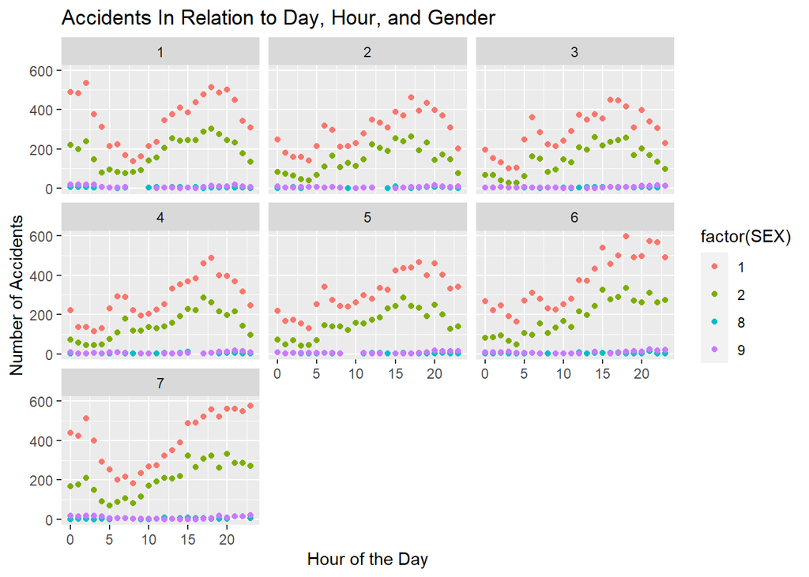

```r
q6 <- q5 %>%
  count(DAY_WEEK, HOUR.x, SEX) %>%
  filter(HOUR.x < 24)
ggplot(q6, aes(x=HOUR.x, y = n, colour = factor(SEX))) + geom_point() + facet_wrap(~ DAY_WEEK) + ggtitle("Accidents In Relation to Day, Hour, and Gender") + xlab("Hour of the Day") + ylab("Number of Accidents")
```

Here it seems that men have the most accidents and these accidents are typically peak around 5pm and these rates are higher on the weekend

Again I had another issue with mapping_data, this might work on your end but it doesn’t compile on mine. It’s hard to test but any partial credit for having the right idea would be greatly appreciated.

```r
#state <- map_data("state")
#c <- map_data("county")

#dat2 <- q2 %>%
#  group_by(COUNTY) %>%
#  summarize(count=n())

#dat3 <- full_join(c,dat2,by=c('group'='COUNTY'))

#ggplot(dat3, aes(x=long,y=lat)) + geom_polygon(aes(group=group, fill = count))
```

Here again I was unable to use map_data. Im hoping on your end this will hopefully run. I commented out everything after using map_data so it will still run generate the markdown on my end.

I apologize for this inconvenience. I really tried everything I could find on the internet and I unistalled and reinstalled r and had no success. 8.

```r
summer = q2 %>% filter(MONTH == 6 | MONTH == 7 | MONTH == 8)
winter = q2 %>% filter(MONTH == 1 | MONTH == 2 | MONTH == 12)

summer_state_deaths = left_join(summer, state_codes, by= c("STATE" = "State Code")) %>%
  group_by(`State Name`) %>% summarise(summer_deaths = n()) %>%
  mutate(`State Name` = tolower(`State Name`))

winter_state_deaths = left_join(winter, state_codes, by= c("STATE" = "State Code")) %>%
  group_by(`State Name`) %>%
  summarise(winter_deaths = n()) %>% mutate(`State Name` = tolower(`State Name`))

#counties <- map_data('county')

#season_state_deaths = left_join(counties, summer_state_deaths, by = c("region" = "State Name"))
#season_state_deaths = left_join(season_state_deaths, winter_state_deaths, by = c("region" = "State Name"))
#season_state_deaths$diff = season_state_deaths$summer_deaths - season_state_deaths$winter_deaths

#ggplot(season_state_deaths, aes(x=long, y=lat, fill=diff))+ geom_polygon(aes(group=group)) + scale_fill_gradient2(midpoint=0, low="blue", #mid="white", high="red")
```